# Diversity in a Globalized World

Lecture 3: People on the Move

Bogdan G. Popescu

bgpopescu@tec.mx

Tecnológico de Monterrey

## Three numbers

- **304 million** people live in a country they were not born in — mid-2024
- That is **3.7%** of humanity — one person in twenty-seven
- Money they send home is worth **more than all foreign aid combined**

Monday’s hit American towns did not empty out. Mexico’s exposed regions were different — people moved.

Today: **why** they leave, where they go, and what follows them back.

## Learning objectives

- Distinguish **immigration**, **emigration** and **net migration**
- Describe the global pattern of migration and remittances
- Explain why development can **increase** emigration
- Explain why migration clusters in networks
- Assess what the evidence says about wages in receiving countries

# I. How Much Migration Is There?

## Most people guess too high

Surveys in rich countries find people **overestimate** the share of migrants around them, usually by more than a factor of two.

Asked how many people in the United States were immigrants, respondents said **36%**. The true figure was about **10%**.

Alesina, Miano & Stantcheva (2023), six-country survey. Their benchmark counts legal immigrants; the foreign-born share on the next map is wider, at 15%. On either definition the guess is more than double the truth.

The interesting fact is not the size. It is the **distribution**.

## Three words to keep straight

| Term | Who it counts | Mexico, 2020 |
| --- | --- | --- |
| **Immigrants** | arrivals — counted where they now live | 1.3 million, or **1%** of people in Mexico |
| **Emigrants** | departures — counted by where they were born | 11.5 million, or **9%** of Mexico’s population |
| **Net migration** | arrivals **minus** departures | about **−150,000** a year |

Same country, same year: the second number is nine times the first. A single “migration” figure cannot stand in for both.

## Where migrants live

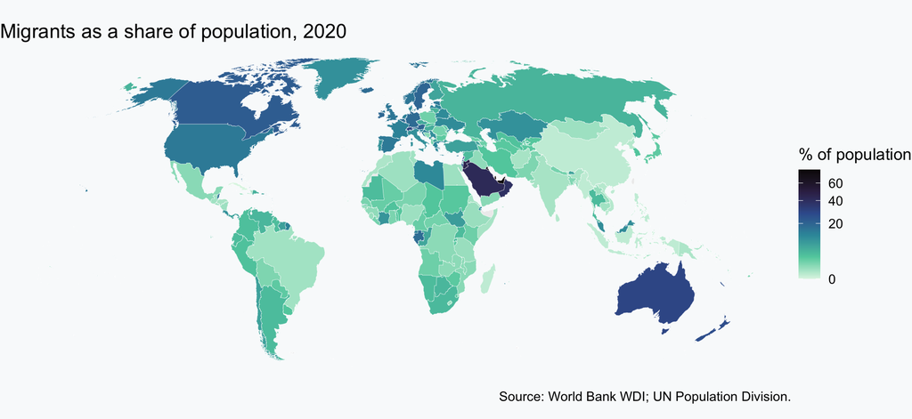

Figure 1

The extremes are small and rich: **Qatar 78%**, the **UAE 76%**, **Kuwait 69%**. The United States is **15%**. Mexico is **1%**.

## Mexico looks untouched

Table 1

| Country | Migrants (%) | Net migration | Remittances (% GDP) |
| --- | --- | --- | --- |
| United Arab Emirates | 76.0 | 92,541 | NA |
| Germany | 18.0 | 203,468 | 0.5 |
| United States | 14.9 | 329,769 | 0.0 |
| Mexico | 1.1 | -147,456 | 3.9 |

Only 1% of people in Mexico were born abroad. But net migration is **negative** and remittances are **4% of GDP**.

## Who gains and who loses

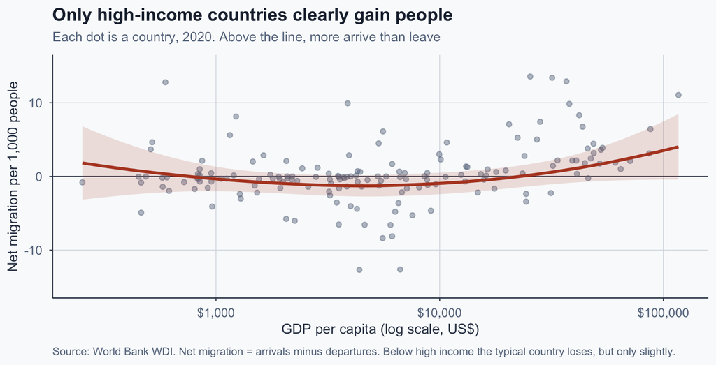

Figure 2

## What that graph cannot show

- Net migration is **arrivals minus departures**
- A country can send many people abroad and still gain people overall
- So we cannot read **emigration** off it

To ask who *leaves*, we have to count people by where they came from, not by where they ended up.

## So what?

- Migration is small globally, concentrated locally
- One map only shows the countries people **arrive** in
- A country can be shaped by migration **without receiving anyone**

To see the other half, we first need to ask why people leave.

# II. Why People Leave

## The wage gap is enormous

The same worker, doing the same job, earns several times more in a rich country than in a poor one.

Clemens (2011) — today’s reading.

Clemens (2011) calls the unrealised gains from this gap **“trillion-dollar bills on the sidewalk.”**

If money were all that mattered, far more people would move than actually do.

## What stops them

```
%%{init: {"flowchart": {"useMaxWidth": true, "htmlLabels": true, "padding": 26,
                        "nodeSpacing": 20, "rankSpacing": 80},
          "themeVariables": {"fontSize": "19px", "fontFamily": "Arial, Helvetica, sans-serif"}} }%%
flowchart LR
  A["Wage gap<br/>abroad"] --> D{"Decide"}
  B["Cost of<br/>travel"] --> D
  C["Visas and<br/>borders"] --> D
  E["Someone<br/>already there"] --> D
  D --> F["Migration"]
```

Figure 3

## Why the poorest often cannot leave

- Moving costs money: transport, documents, months without earnings
- The very poorest cannot pay those costs
- So emigration is **low** in the poorest countries

If that is right, emigration should be **low** at the bottom of the income scale, **higher** in the middle, and low again at the top. We can check it.

## Emigration peaks in the middle

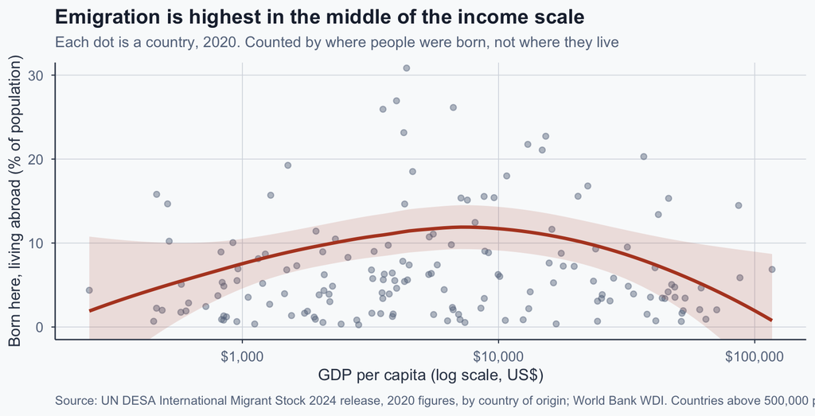

Figure 4

## The hump, in medians

Table 2

| GDP per capita | Countries | Median % living abroad |
| --- | --- | --- |
| under $2,000 | 44 | 3.9 |
| $2,000–5,000 | 40 | 5.7 |
| $5,000–15,000 | 37 | 7.4 |
| $15,000–40,000 | 25 | 5.8 |
| over $40,000 | 21 | 3.5 |

The poorest band and the richest band send out about the same modest share. The middle sends out roughly twice as much.

## What lifts the rising half

- **Being able to pay** — the mechanism in the village exercise
- **Who is in the population** — more schooling means more people with portable skills
- **Networks** — each cohort abroad makes the next trip cheaper and safer

## Why migration clusters

- The first migrant faces the highest cost and the greatest risk
- The second follows a known route, to a known contact
- Each arrival lowers the cost for the next

Munshi (2003) shows this for Mexican migrants: those with **larger established networks** in the United States were more likely to be employed on arrival.

## Exercise 1 — Who gets to leave?

One village. The same job in the United States pays any of them **250,000 pesos a year**. Getting there costs **100,000 pesos**, all of it paid before you leave — and in this village that is the **only** way north.

| Household | Earns at home | Can put up now |
| --- | --- | --- |
| **Ana** | 40,000 | 10,000 saved |
| **Beto** | 55,000 | 60,000 — four years of saving |
| **Carmen** | 45,000 | 20,000, and a sister in Houston who will send whatever is missing |
| **Diego** | 400,000 | 150,000; owns the village shop |

*A household leaves if it can cover the whole cost before departure, and would earn more abroad than at home.*

**1. Who leaves?** **2. A new road and a cheaper bus halve the cost, to 50,000. Whose answer changes?**

Five minutes, in pairs.

## Exercise 1 — Responses

| Household | Leaves? |  |
| --- | --- | --- |
| **Ana** | no | 10,000 against 100,000 — and still no at 50,000 |
| **Beto** | not yet | saved for four years and is 40,000 short |
| **Carmen** | **yes** | poorer than Beto, goes anyway — the sister *is* the finance |
| **Diego** | no | the only one who could pay cash, the only one with no gap to close |

**Q2: Beto’s answer, and only Beto’s.** He earns 55,000 — barely more than Ana. The road reaches the household just above the one it cannot help.

> Both ends of the scale stay home, and cheaper travel does not reach the bottom. Migration comes from the middle.

## ▶ The cheapest ticket

[video not shown]

Channel 4 News, *Riding ‘The Death Train’ to America’s border* (2018), reporter Guillermo Galdos. Excerpt shown for teaching.

## The poorest cannot leave. Or can they?

We have just concluded that **Ana stays**: the trip costs more than she has, at either price.

Dunia’s family has almost nothing — and they are already a thousand miles into the journey.

**1. Does the video contradict the exercise?**

**2. If you cannot pay in money, what do you pay in instead?**

Three minutes, in pairs.

## What the model leaves out

| In the exercise | In the video |
| --- | --- |
| People leave for **higher wages** | Dunia’s family leaves because **staying is dangerous** |
| **One route**, one price, paid in cash | **Several routes**, paid in cash, time or risk |
| Cannot pay → **stays** | Cannot pay → **takes the cheaper, deadlier route** |

> The constraint does not only decide **whether** people move. It decides **how**.

This does not overturn the chart. Poorer countries still send a smaller share of their people, and a tendency across 167 countries was never a claim about every family. What it overturns is the idea that “cannot afford it” means “stays at home”.

## So what?

Everyone who leaves is still connected to the place they left. That connection has a price, and it is measurable.

# III. The Money That Comes Back

## Remittances: the second map

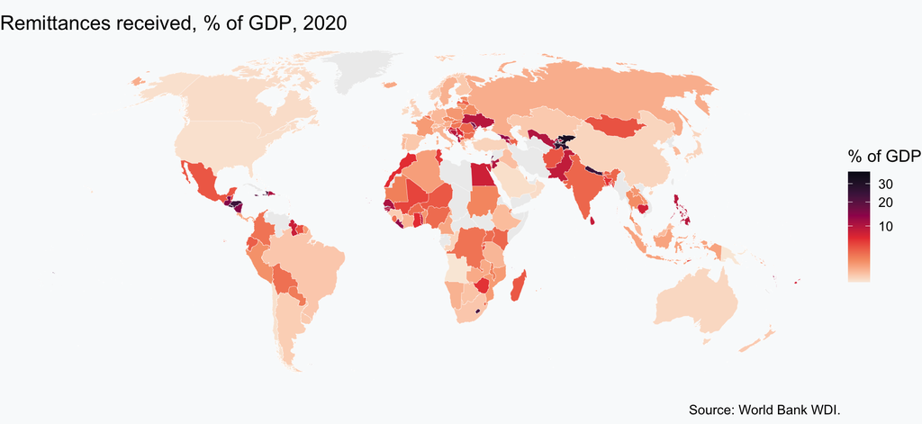

Figure 5

## Almost the opposite map

- Map 1 was dark in the Gulf, North America, Australia
- Map 2 is dark in Central America, the Caucasus, West Africa
- Same phenomenon, seen from each end

Mexico is pale on the first map and clearly visible on the second.

The most dependent economies are small ones: Kyrgyzstan **32%** of GDP, Tajikistan **27%**, Nepal **24%**.

## Mexico, 1990 to 2023

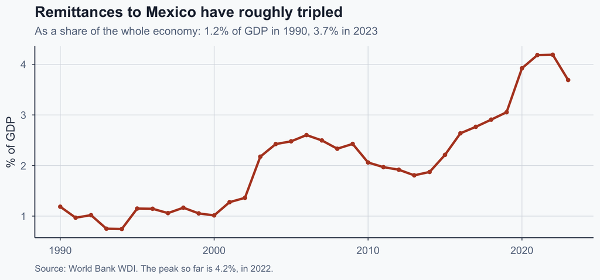

Figure 6

## What that money does

- It goes to households, not governments
- It often rises when the household **back home** is hit by a shock
- It is more stable than foreign investment during crises

Yang (2011) reviews the evidence: remittances raise consumption and schooling, and cushion shocks.

The insurance only runs one way. When it is the *migrant* who loses work, or the host economy that turns down, remittances can fall exactly when they are most needed.

## The other side of the money

Remember who leaves: rarely the poorest. Leaving costs money.

- So remittances tend to reach the households that could **cover the trip** — by saving, or through a relative already abroad
- Where that holds, they can **widen** the gap inside a village rather than close it
- Where networks reach further down, they can narrow it

## Is more leaving a problem?

**DEBATE: Make the journey cheap and safe, and more people will go. Is that a failure?**

**FOR:** Sending countries lose working-age people they paid to raise and educate.

**AGAINST:** Those who leave are far better off, and what they send home dwarfs all foreign aid.

You now have both halves of the ledger: what the sending country loses, and the 3.7% of Mexico’s economy that comes back.

## So what?

- Migration binds two economies together, not one
- The receiving country gains workers; the sending country gains income
- Neither map alone describes what happened

Which leaves the question everyone actually argues about.

# IV. What Migration Does to Wages

## The question everyone asks

**Do migrants lower wages for workers already there?**

The theory is simple: more workers, same jobs, lower pay.

Testing it is hard, because migrants choose where to go — they move to places already doing well.

## Why the simple theory can fail

“More workers, same jobs” assumes the jobs stay the same. Three reasons they do not:

- **Arrivals are not copies of the people already there.** Different skills complement rather than replace, and natives move into the work where they hold the advantage
- **Arrivals are also customers.** They rent, eat and buy, raising the demand for labour as well as the supply of it
- **Firms react.** Where workers are easier to find, businesses expand and new ones open

## A natural experiment

- April 1980: Cuba briefly allowed emigration from the port of Mariel
- About **125,000 people** left for Florida in six months
- Miami’s labour force grew roughly **7%** almost overnight
- Miami’s labour supply jumped for reasons unrelated to Miami’s economy

## Mariel, 1980

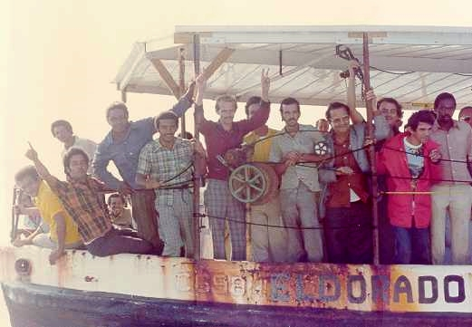

Cuban refugees arriving in Florida during the Mariel boatlift, 1980. Source: [Wikimedia Commons](https://commons.wikimedia.org/wiki/File:Mariel_Refugees.jpg), public domain.

## Two economists, one event

- **Card (1990):** Miami against four similar cities → **no measurable effect** on wages
- **Borjas (2017):** only non-Hispanic men, 25–59, without a high-school diploma → a **large fall**
- **Peri & Yasenov (2019); Clemens & Hunt (2019):** same data, re-examined → the fall **does not survive**

So the argument is not about what happened in Miami. It is about **which workers you count**.

Borjas’s group is a few dozen men a year in the survey. The share of Black workers in that small sample rose sharply after 1980, and Clemens and Hunt show that alone can produce the drop.

## Why they disagree

One event, two designs:

|  | Card (1990) | Borjas (2017) |
| --- | --- | --- |
| **Whose wages** | whites, Blacks, non-Cuban Hispanics and Cubans, split by income quartile | non-Hispanic men, 25–59, no high-school diploma |
| **Compared with** | Atlanta, Houston, Los Angeles and Tampa, averaged | several alternative control groups |
| **How many people** | the city’s workforce | a few dozen men a year |
| **Answer** | no measurable effect | a large fall |

Neither is cheating. The design choices **are** the finding — which is why Peri & Yasenov and Clemens & Hunt could re-run the same data and recover Card’s answer.

## What we can say

- Average effects on wages are **small** in most studies
- Effects concentrate on workers most similar to arrivals
- The answer depends heavily on how you define the comparison group

## Exercise 2 — Design the test

**1. Which city would you use? What goes wrong with it?**

| Atlanta | Los Angeles | Tampa |
| --- | --- | --- |
| no big arrivals; economy growing fast in the 1980s | a gateway city — new arrivals every year | same state; smaller, older, more retirees |

**2. Whose wages would you look at — and what would that choice let you say?** all workers · no high-school diploma · construction workers · Cubans already in Miami

Five minutes, in pairs.

## Exercise 2 — Responses

**The city.** Card used **four averaged together** — Atlanta, Houston, Los Angeles, Tampa — so no single city’s quirks decide the answer.

**The workers.** There is no single right answer here — each choice answers a different question.

| Whose wages | What it can tell you | What it costs you |
| --- | --- | --- |
| **All workers** | the average effect on the city | a real effect on a small group disappears into the average |
| **No high-school diploma** | the effect where competition should bite hardest | the sample shrinks fast — the Borjas problem |
| **Cubans in Miami** | the effect on the closest substitutes | also the group most tied into the arrivals’ own networks |
| **Construction** | the effect in one exposed sector | moves with Miami’s building cycle, not just with arrivals |

Card reported several of these, including Cubans and workers by income quartile.

> A good comparison is not a city that **looks** like Miami. It is one that was **moving** like Miami until 1980.

And matching trends before 1980 is the strongest check available, not a proof. It cannot rule out that something else hit Miami and the control cities differently in exactly those years.

## Takeaways

1. Migration is **3.7%** of humanity, very unevenly placed
2. Development **raises** emigration before it lowers it
3. Networks make migration self-reinforcing
4. Remittances bind sending and receiving economies together
5. Wage effects are small on average, contested at the margins

> A country can be transformed by migration without a single migrant arriving.

## References

Alesina, A., Miano, A., & Stantcheva, S. (2023). Immigration and redistribution. *The Review of Economic Studies, 90*(1), 1–39.

Borjas, G. J. (2017). The wage impact of the Marielitos: A reappraisal. *Industrial and Labor Relations Review, 70*(5), 1077–1110.

Card, D. (1990). The impact of the Mariel boatlift on the Miami labor market. *Industrial and Labor Relations Review, 43*(2), 245–257.

Clemens, M. A. (2011). Economics and emigration: Trillion-dollar bills on the sidewalk? *Journal of Economic Perspectives, 25*(3), 83–106.

Clemens, M. A., & Hunt, J. (2019). The labor market effects of refugee waves: Reconciling conflicting results. *ILR Review, 72*(4), 818–857.

Clemens, M. A. (2014). Does development reduce migration? In R. E. B. Lucas (Ed.), *International Handbook on Migration and Economic Development* (pp. 152–185). Edward Elgar.

Dao, T. H., Docquier, F., Parsons, C., & Peri, G. (2018). Migration and development: Dissecting the anatomy of the mobility transition. *Journal of Development Economics, 132*, 88–101.

## References (cont.)

Docquier, F., & Rapoport, H. (2012). Globalization, brain drain, and development. *Journal of Economic Literature, 50*(3), 681–730.

National Academies of Sciences, Engineering, and Medicine. (2017). *The Economic and Fiscal Consequences of Immigration*. Washington, DC: National Academies Press.

Munshi, K. (2003). Networks in the modern economy: Mexican migrants in the U.S. labor market. *Quarterly Journal of Economics, 118*(2), 549–599.

Peri, G., & Yasenov, V. (2019). The labor market effects of a refugee wave: Synthetic control method meets the Mariel boatlift. *Journal of Human Resources, 54*(2), 267–309.

Parreñas, R. S. (2005). *Children of Global Migration: Transnational Families and Gendered Woes*. Stanford University Press.

United Nations, Department of Economic and Social Affairs. (2021). *International Migrant Stock 2020*. New York: United Nations.

United Nations, Department of Economic and Social Affairs. (2025). *International Migrant Stock 2024*. New York: United Nations.

World Bank. (2024). *World Development Indicators*. Washington, DC: World Bank.

Yang, D. (2011). Migrant remittances. *Journal of Economic Perspectives, 25*(3), 129–152.